# Afternoon Exercises

1. Read in both PM_Borders1.csv and PM_Borders2.csv separately using `read_csv()`. Remember to load the `readr` package first.

```r
library(readr)

# Read in PM_Borders1.csv

PM_Borders1 <- read_csv("data/PM_Borders1.csv")

# Read in PM_Borders2.csv

PM_Borders2 <- read_csv("data/PM_Borders2.csv")
```

2. `PM_Borders1` and `PM_Borders2` have the same columns and there are some records that exist within both files. Choose an appropriate join function to merge these data frames together and call this `joined_data`.

```r
# Use full_join to merge these files

joined_data <- full_join(PM_Borders1, PM_Borders2)

# Show data

joined_data
```

```
## # A tibble: 2,000 x 25
##      URI HospitalCode Specialty ManagementofPat~ Main_Condition Main_op
##    <dbl> <chr>        <chr>     <chr>            <chr>          <chr>
##  1     1 B102H        E12       Inpatient        S4230          <NA>
##  2     2 B114H        E12       Inpatient        C785           <NA>
##  3     3 B114H        E12       Inpatient        G20X           <NA>
##  4     4 B120H        C8        Inpatient        T814           W283
##  5     5 B120H        AB        Inpatient        R02X           <NA>
##  6     6 B120H        C7        IP originally a~ H269           C751
##  7     7 B120H        A1        Inpatient        I269           X558
##  8     8 B120H        C8        Inpatient        M169           W371
##  9     9 B120H        A1        Inpatient        K922           X339
## 10    10 B120H        A1        Inpatient        J969           <NA>
## # ... with 1,990 more rows, and 19 more variables: Dateofbirth <dbl>,
## #   DateofAdmission <dbl>, DateofDischarge <dbl>, Sex <chr>,
## #   Postcode <chr>, LinkNo <dbl>, LengthOfStay <dbl>, HBRes <chr>,
## #   dob_year <lgl>, spec_1 <chr>, birthdate <chr>, admissiondate <chr>,
## #   dischargedate <chr>, ageonadmission <dbl>, ageondischarge <dbl>,
## #   lengthofstay1 <dbl>, LOS_difference <dbl>, admissionday <dbl>,
## #   dischargeday <dbl>
```

```r
# Compare dimensions

dim(PM_Borders1)
```

```
## [1] 1200   25
```

```r
dim(PM_Borders2)
```

```
## [1] 1000   25
```

```r
dim(joined_data)
```

```
## [1] 2000   25
```

3. Using `joined_data`, create a crosstab of `ManagementofPatient` and `Specialty`.

```r
# Use table() to get the crosstab

table(joined_data$ManagementofPatient, joined_data$Specialty)
```

```
##
##                                                            A1  A2  A6  A7
##   Day Case - Other than in Day Bed Unit or Inpatient Ward  12   0   0   0
##   Day Case in Day Bed Unit                                 19   1   0   0
##   Day Case in Inpatient Ward                               64  11   0   0
##   Inpatient                                               359   8   2   2
##   IP originally admitted as Day Case in Day Bed Unit        0   0   0   0
##   IP originally admitted as Day Case in Inpatient Ward      0   1   1   0
##
##                                                            A9  AB  AD  AF
##   Day Case - Other than in Day Bed Unit or Inpatient Ward   0   0  11   0
##   Day Case in Day Bed Unit                                  6   0   0   0
##   Day Case in Inpatient Ward                                3   0   0   0
##   Inpatient                                                 8  79   3  93
##   IP originally admitted as Day Case in Day Bed Unit        0   0   0   0
##   IP originally admitted as Day Case in Inpatient Ward      0   0   0   0
##
##                                                            AG  AH  AM  AP
##   Day Case - Other than in Day Bed Unit or Inpatient Ward   0   0   0   0
##   Day Case in Day Bed Unit                                  0   1   0   0
##   Day Case in Inpatient Ward                                0   0   0   0
##   Inpatient                                                 5   6   5   3
##   IP originally admitted as Day Case in Day Bed Unit        0   0   0   0
##   IP originally admitted as Day Case in Inpatient Ward      0   0   0   0
##
##                                                            AQ  C1 C11 C12
##   Day Case - Other than in Day Bed Unit or Inpatient Ward   0   0  30   0
##   Day Case in Day Bed Unit                                  0   1  65   0
##   Day Case in Inpatient Ward                                0   0   1   0
##   Inpatient                                                 6   3 193   5
##   IP originally admitted as Day Case in Day Bed Unit        0   0   2   0
##   IP originally admitted as Day Case in Inpatient Ward      0   0   0   0
##
##                                                            C2  C3  C4 C41
##   Day Case - Other than in Day Bed Unit or Inpatient Ward   0   2   0   0
##   Day Case in Day Bed Unit                                  0   5   0   0
##   Day Case in Inpatient Ward                                0   0   0   0
##   Inpatient                                                 1  29   1   4
##   IP originally admitted as Day Case in Day Bed Unit        0   0   0   0
##   IP originally admitted as Day Case in Inpatient Ward      0   0   0   0
```

[output cut: 17 more lines]

```
##                                                            D3  D8 E12  F2
##   Day Case - Other than in Day Bed Unit or Inpatient Ward  60   0   0   0
##   Day Case in Day Bed Unit                                 39   0   0  30
##   Day Case in Inpatient Ward                                0   0   0  20
##   Inpatient                                                 2   1 138  75
##   IP originally admitted as Day Case in Day Bed Unit        1   0   0   2
##   IP originally admitted as Day Case in Inpatient Ward      0   0   0   0
##
##                                                            H1  H2  J4
##   Day Case - Other than in Day Bed Unit or Inpatient Ward   9   4   4
##   Day Case in Day Bed Unit                                  1  82  28
##   Day Case in Inpatient Ward                                0   5   3
##   Inpatient                                                 0  22  20
##   IP originally admitted as Day Case in Day Bed Unit        0   0   1
##   IP originally admitted as Day Case in Inpatient Ward      0   1   0
```

4. Take all records in `joined_data` which have `ManagementofPatient` values “Day Case in Inpatient Ward” or “Day Case in Day Bed Unit” and store them in a dataframe called `day_cases`. Calculate a new column `LOS2` for `LengthOfStay` multiplied by two.

```r
# Use filter() to select values and mutate() to calculate LOS2

day_cases <- joined_data %>%
  filter(ManagementofPatient == "Day Case in Inpatient Ward" | ManagementofPatient == "Day Case in Day Bed Unit") %>%
  mutate(LOS2 = LengthOfStay * 2)

# Show data

day_cases %>% select(ManagementofPatient, LengthOfStay, LOS2)
```

```
## # A tibble: 528 x 3
##    ManagementofPatient        LengthOfStay  LOS2
##    <chr>                             <dbl> <dbl>
##  1 Day Case in Inpatient Ward            2     4
##  2 Day Case in Inpatient Ward            3     6
##  3 Day Case in Day Bed Unit              1     2
##  4 Day Case in Day Bed Unit              2     4
##  5 Day Case in Inpatient Ward            0     0
##  6 Day Case in Day Bed Unit              0     0
##  7 Day Case in Day Bed Unit              0     0
##  8 Day Case in Inpatient Ward            0     0
##  9 Day Case in Day Bed Unit             10    20
## 10 Day Case in Day Bed Unit              0     0
## # ... with 518 more rows
```

5. Group `joined_data` by `Specialty` and then calculate the mean `LengthOfStay` value for each `Specialty`. Arrange the data by mean `LengthOfStay` from largest to smallest.

```r
# Use group_by() to group the data and then use summarise() to calculate the mean length of stay. Use arrange() to sort the data

joined_data %>%
  group_by(Specialty) %>%
  summarise(mean_los = mean(LengthOfStay)) %>%
  arrange(desc(mean_los))
```

```
## # A tibble: 35 x 2
##    Specialty mean_los
##    <chr>        <dbl>
##  1 C9           17.2
##  2 AG           11.2
##  3 CA            7.44
##  4 F2            6.05
##  5 H1            5.5
##  6 C11           4.60
##  7 AB            4.59
##  8 C8            4.59
##  9 C41           4.25
## 10 AD            4
## # ... with 25 more rows
```

6. Select the `LinkNo`, `HospitalCode` and `Main_op` columns in `joined_data` and rename the `Main_op` column to `Main_Operation`. Store this data in a dataframe called `filtered_data` and only keep records that do not have a missing value for `Main_Operation`. How many records have been removed?

```r
# Use select() to select columns and rename() to rename Main_op
# Use filter() and !is.na() to obtain records which do not have a missing value

filtered_data <- joined_data %>%
  select(LinkNo, HospitalCode, Main_op) %>%
  rename(Main_Operation = Main_op) %>%
  filter(!is.na(Main_Operation))

nrow(joined_data) - nrow(filtered_data)
```

```
## [1] 697
```

7. Plot a histogram of `LengthOfStay` for records in `joined_data` with a `DateofAdmission` in April 2015. Give your histogram a suitable title, colour and axis labels.

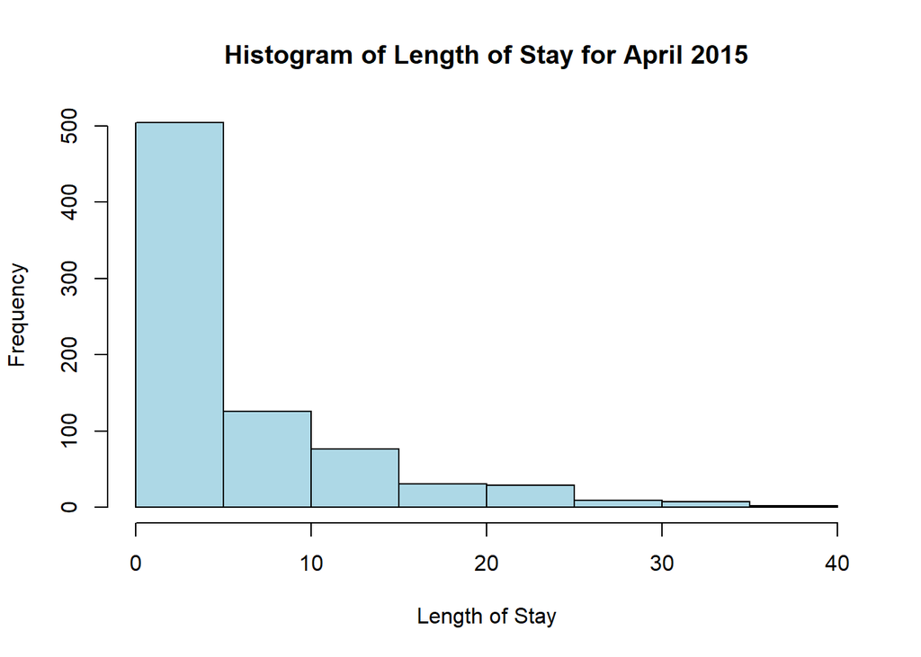

```r
hist_data <- joined_data %>%
  filter(DateofAdmission >= 20150401 & DateofAdmission <= 20150430)

hist(hist_data$LengthOfStay, col = "lightblue", main = "Histogram of Length of Stay for April 2015", xlab = "Length of Stay", ylab = "Frequency")
```